# Vehicle Fuel Economy Estimates, 1984-2017

## Preliminary Wrangling

The purpose of EPA’s fuel economy estimates is to provide a reliable basis for comparing vehicles. Most vehicles in the database (other than plug-in hybrids) have three fuel economy estimates: a “city” estimate that represents urban driving, in which a vehicle is started in the morning (after being parked all night) and driven in stop-and-go traffic; a “highway” estimate that represents a mixture of rural and interstate highway driving in a warmed-up vehicle, typical of longer trips in free-flowing traffic; and a “combined” estimate that represents a combination of city driving (55%) and highway driving (45%). Estimates for all vehicles are based on laboratory testing under standardized conditions to allow for fair comparisons.

EPA’s fuel economy values are good estimates of the fuel economy a typical driver will achieve under average driving conditions and provide a good basis to compare one vehicle to another. However, your fuel economy may be slightly higher or lower than EPA’s estimates. Fuel economy varies, sometimes significantly, based on driving conditions, driving style, and other factors.The data we will be looking at is taken from https://www.kaggle.com/epa/fuel-economy. This data set contains 38113 row with 81 variables.

## Distribution of Cars Company

The most used cars are Chevrolet , which is approximately 4000 users, followed by Ford, which are two powerful American companies, then it is followed by some American companies and others such as the Japanese and others

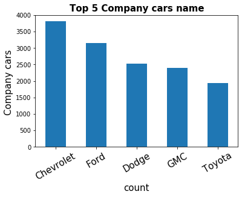

```python
fig, ax = plt.subplots()

ax.tick_params(axis='x', labelsize=15)
ax.tick_params(axis='y', labelsize=10)

ax.set_xlabel('count', fontsize=15)
ax.set_ylabel('Company cars ' , fontsize=15)
ax.set_title('Top 5 Company cars name', fontsize=15, fontweight='bold')

fuelMake[:5].plot(ax=ax, kind='bar')

plt.xticks(rotation=30);
```

## Annual Fuel Cost vs Annual Consumption in Barrels

Fuel costs and their consumption on an annual basis. It is reasonable to assume that the more shrimp is consumed, the greater its value. This applies to fuel, and it is a positive sign, although the costs increase, but this is profitable for the state as well.

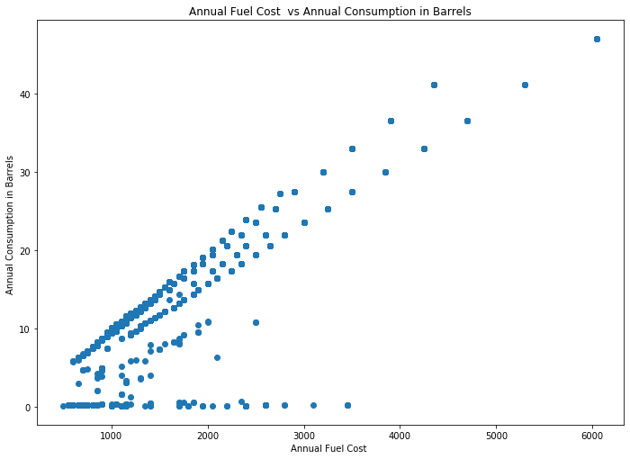

```python
# scatter plot of Annual Fuel Cost (FT1) vs Annual Consumption in Barrels (FT1)

plt.figure(figsize = [11.69, 8.27])
plt.scatter(data = fuel, x = 'Annual Fuel Cost (FT1)', y = 'Annual Consumption in Barrels (FT1)')
plt.xlabel('Annual Fuel Cost ')
plt.ylabel('Annual Consumption in Barrels ')
plt.title('Annual Fuel Cost  vs Annual Consumption in Barrels')
plt.show()
```

## Drive Type , Engine Cylinders and Fuel Type

We note that the higher driving type is the rear wheel and front wheel drive, which is economical. The most cylinders are 4 and then 6 and are somewhat uneconomical for the 6. The type of fuel is important in the economy, the most important of which is regular, but there is something strange about it, which is diesel. It is known that diesel is economical.

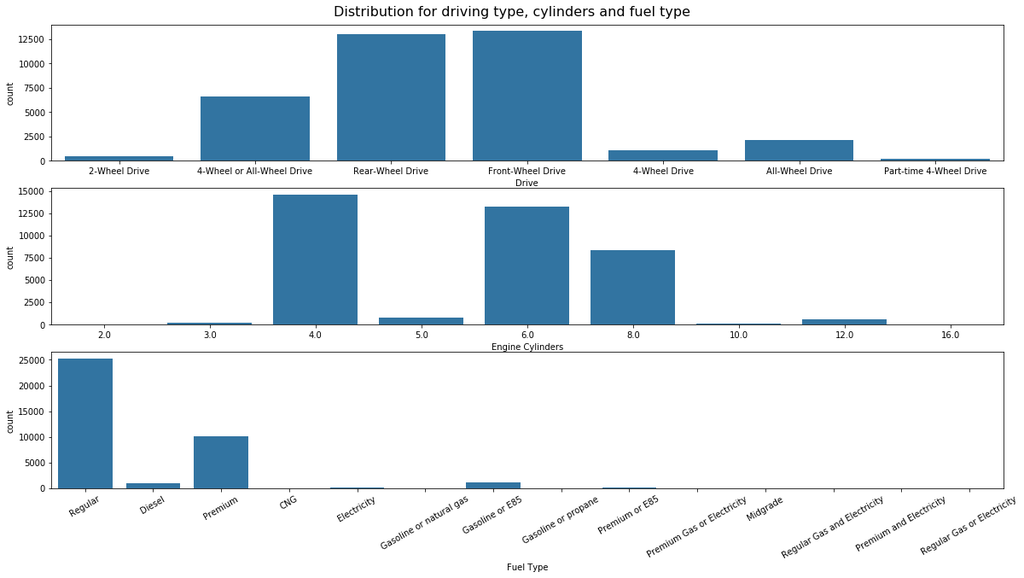

```python
fig, ax = plt.subplots(nrows=3, figsize = [20,10])
default_color = sb.color_palette()[0]
g1 = sb.countplot(data = fuel, x = 'Drive', color = default_color, ax = ax[0])
g2 = sb.countplot(data = fuel, x = 'Engine Cylinders', color = default_color, ax = ax[1])
g3 = sb.countplot(data = fuel, x = 'Fuel Type', color = default_color, ax = ax[2])

fig.suptitle('Distribution for driving type, cylinders and fuel type', fontsize=16, y=.91)

plt.xticks(rotation=30);
```

## Engine Cylinders ,Engine Displacement and Combined MPG

After looking at the demo, it became clear that the greater the number of cylinders, the greater the displacement, and this reflects the engine's power. Also, it turns out that the higher the Combined MPG (FT1), the lower the number of cylinders and the displacement, which means that fuel is saved with it.

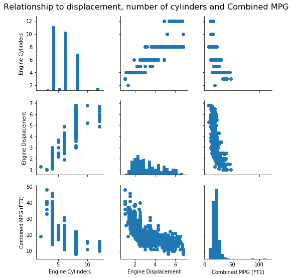

```python
# plot matrix: sample 2000 loans so that plots are clearer and render faster

samples = np.random.choice(fuel.shape[0], 2000, replace = False)
fuel_samp = fuel.loc[samples,:]
plt.figure(figsize = [11.69, 8.27])
g = sb.PairGrid(data = fuel_samp, vars = numeric_vars)
g = g.map_diag(plt.hist, bins = 20);
g.fig.suptitle("Relationship to displacement, number of cylinders and Combined MPG ", fontsize=16, y = 1.02)

g.map_offdiag(plt.scatter)
plt.show();
```

## chargers relation of Engine Cylinders ,Engine Displacement andCombined MPG

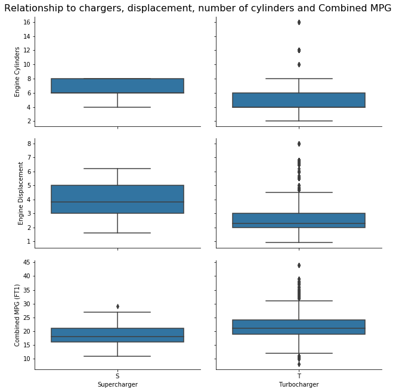

```python
# plot matrix of numeric features against categorical features.

def boxgrid(x, y, **kwargs):
    """ Quick hack for creating box plots with seaborn's PairGrid. """
    default_color = sb.color_palette()[0]
    sb.boxplot(x, y, color = default_color)


plt.figure(figsize = [11.69, 8.27])
g = sb.PairGrid(data = fuel, y_vars = ['Engine Cylinders', 'Engine Displacement', 'Combined MPG (FT1)'],
                x_vars = categoric_vars, size = 3, aspect = 1.5)
g.fig.suptitle("Relationship to chargers, displacement, number of cylinders and Combined MPG ", fontsize=16 , y =1.01)
g.map(boxgrid)
plt.show();
```

## Fuel Type on Drive and Highway Range

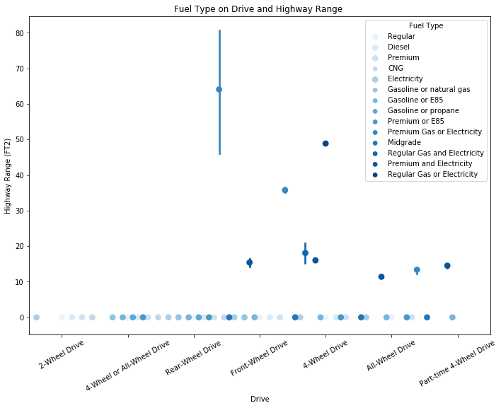

```python
fig = plt.figure(figsize = [11.69, 8.27])
ax = sb.pointplot(data = fuel, x = 'Drive', y = 'Highway Range (FT2)', hue = 'Fuel Type',
           palette = 'Blues', linestyles = '', dodge = 2)
plt.title('Fuel Type on Drive and Highway Range ')
plt.ylabel('Highway Range (FT2)')
plt.xlabel('Drive')
ax.set_yticklabels([],minor = True)
plt.xticks(rotation=30);
plt.show();
```

## Chargers By Combined MPG and Fuel Type

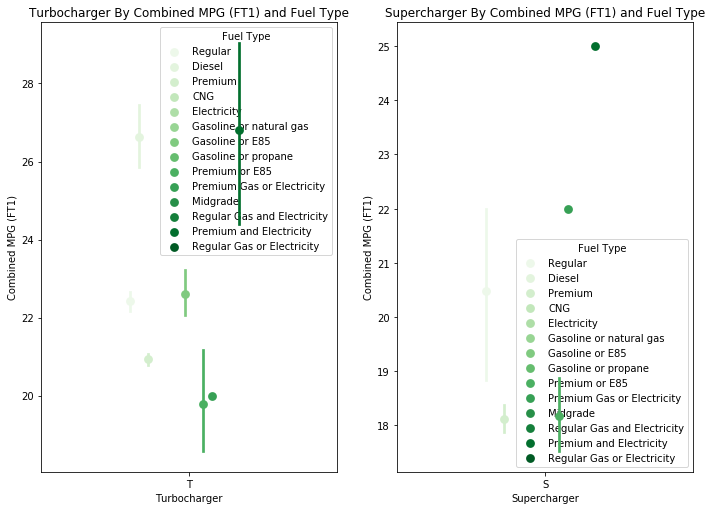

```python
fig, ax = plt.subplots(ncols = 2, figsize = [11.69, 8.27])

sb.pointplot(data = fuel, x = 'Turbocharger', y = 'Combined MPG (FT1)', hue = 'Fuel Type',
             palette = 'Greens', linestyles = '', dodge = 0.4, ax = ax[0])
ax[0].set_title('Turbocharger By Combined MPG (FT1) and Fuel Type')
ax[0].set_ylabel('Combined MPG (FT1)')

ax[0].set_yticklabels([],minor = True)

sb.pointplot(data = fuel, x = 'Supercharger', y = 'Combined MPG (FT1)', hue = 'Fuel Type',
             palette = 'Greens', linestyles = '', dodge = 0.4, ax = ax[1])
ax[1].set_title('Supercharger By Combined MPG (FT1) and Fuel Type')
ax[1].set_ylabel('Combined MPG (FT1)')

ax[1].set_yticklabels([],minor = True)
plt.show();
```

```python
!jupyter nbconvert  Vehicle_Fuel_Economy_Estimates_1984-2017_part2.ipynb --to slides --post serve --template output_toggle
### my software system it's ios mac
```

[output not shown]